# FinalReportfor 112

2023-04-25

## Data Context

Our dataset consists of information on every game played in each men’s March Madness basketball tournament from 1985-2016. Each unit of observation is a single March Madness game. Variables contained in our dataset include the date of each game, the losing and winning team names, the losing and winning scores, the round of the tournament, the region of the tournament, and whether or not the game went to overtime. We found and acquired this dataset on dataworld.com under the following URL: https://data.world/sports/ncaa-mens-march-madness

The NCAA Division I men’s basketball tournament, branded as NCAA March Madness and commonly called March Madness, is a single-elimination tournament played in the United States to determine the men’s college basketball national champion of the Division I level in the National Collegiate Athletic Association (Wikipedia). A total of 64 teams participate in the tournament, which consists of several rounds starting with the First Round and ending with the National Championship. Teams are seeded 1-16, with 4 teams occupying each seed number, by a committee according to their regular season record, strength of schedule, advanced metrics, etc. A team can earn an automatic bid into the tournament by winning their conference’s conference tournament. The first round matchups are organized by seed, with 1 seeds playing 16 seeds, 2 seeds playing 15 seeds, and so on. Each individual game consists of two 20 minute halves. At the end of the game, the team with the most points wins and advances to the next round. The last team standing is declared the men’s Division 1 Basketball champion for that year.

## Research Question

> Has the men’s March Madness basketball tournament become more competitive from 1985 to 2016?

Perhaps the most exciting and entertaining aspect of the annual men’s March Madness basketball tournament is the thrilling games that go down to the wire and the stunning upsets that seem to happen more with each passing year. But has March Madness actually become more competitive over time as a whole, or does it only seem that way? We believe this question is quite interesting and relevant to the tournament, as it is largely unpredictable on a year by year basis, so we wanted to look at tournament trends over the course of 30 years instead.

## Data Cleaning

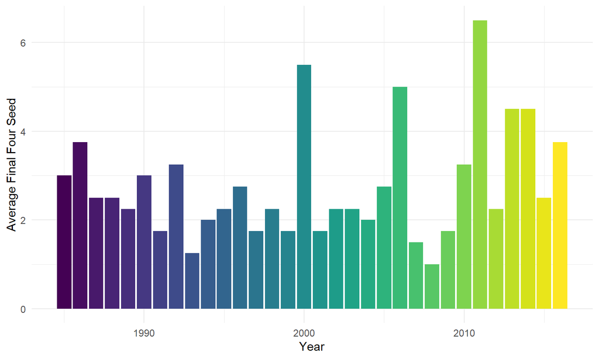

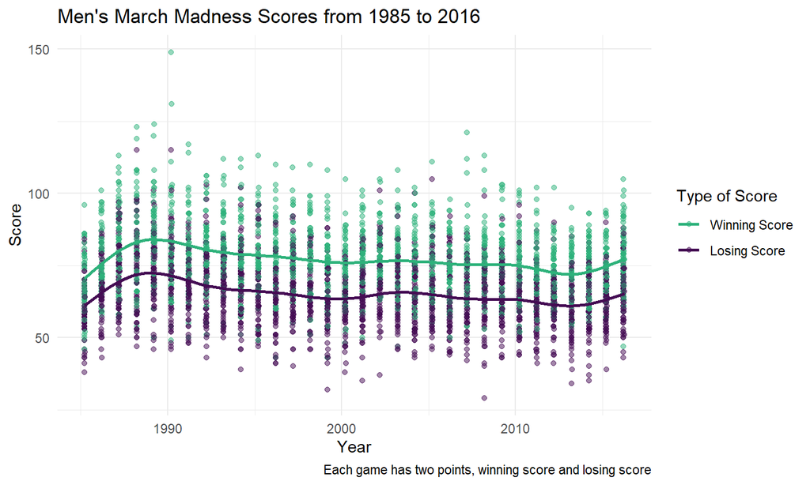

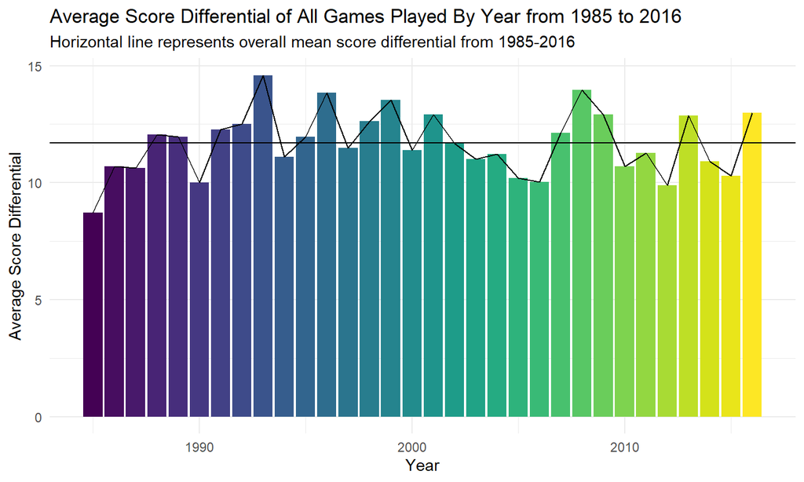

```
## # A tibble: 1 × 1
##   `mean(ScoreDifferential)`
##                       <dbl>
## 1                      11.7
```

## Analysis

This bar graph displays the average score differential of every game played in each men’s March Madness basketball tournament from 1985 to 2016. The average score differentials for each year were calculated by subtracting the losing team’s score from the winning team’s score from each game in each year, then adding all of these score differentials together and dividing that sum by the total number of games, for each year in our dataset. This graph is seeking to determine if March Madness has become more competitive over time by investigating if the tournament games are becoming more closely contested on average over a longer period of time.

The main takeaway from this graph is that it is largely inconclusive. Looking at the trend line, there is no discernible constant trend in either direction, rather, the average score differentials seem to fluctuate unpredictably by year. Moreover, the distribution of the average score differentials from 2010-2016 appears very similar to the distribution from 1985-1990, which suggests that there has been little change in the average score differentials in this 30 year time period. Therefore, this graph leads me to conclude that March Madness has NOT become more competitive over time, rather, its competitiveness fluctuates on a year to year basis, with no observable trend over a longer period of time.

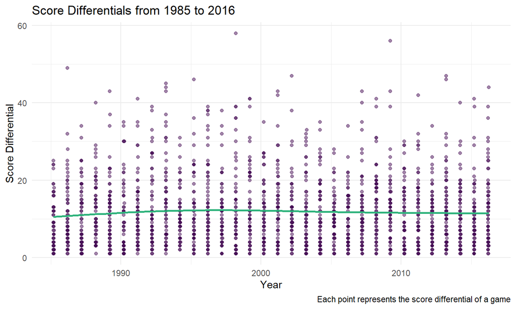

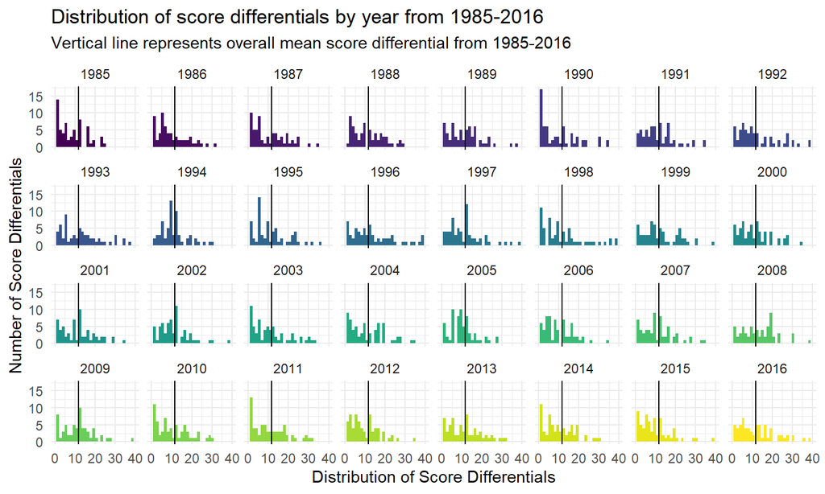

## Analysis

This faceted histogram displays the distribution of the score differentials of all games played in each men’s March Madness tournament from 1985-2016. This graph is seeking to analyze the shape, center, and spread of these histograms over a long period of time to determine if March Madness games are becoming closer over time.

On a year by year scale, there are some significant fluctuations, such as the drastic increase in games with a low score differential from 1989 to 1990, but in 1991, the distribution is almost the same as it was in 1989 before the increase. This exemplifies the extremely unpredictable nature of March Madness as a whole, and how the score differentials may fluctuate far away from the “mean” over the course of one or a few years, but over a longer period of time, the differentials return back to the mean. Therefore, this graph leads me to conclude that March Madness has NOT become more competitive over time. On a year to year basis, there are some noticeable differences in the distribution of score differentials, but over a longer period of time, these differences even out, meaning that any differences that were observed were likely fluke outcomes. While March Madness games may have become more competitive over the course of a few years, in the interest of our investigation, there has been little variation in how competitive March Madness has been from 1985-2016.

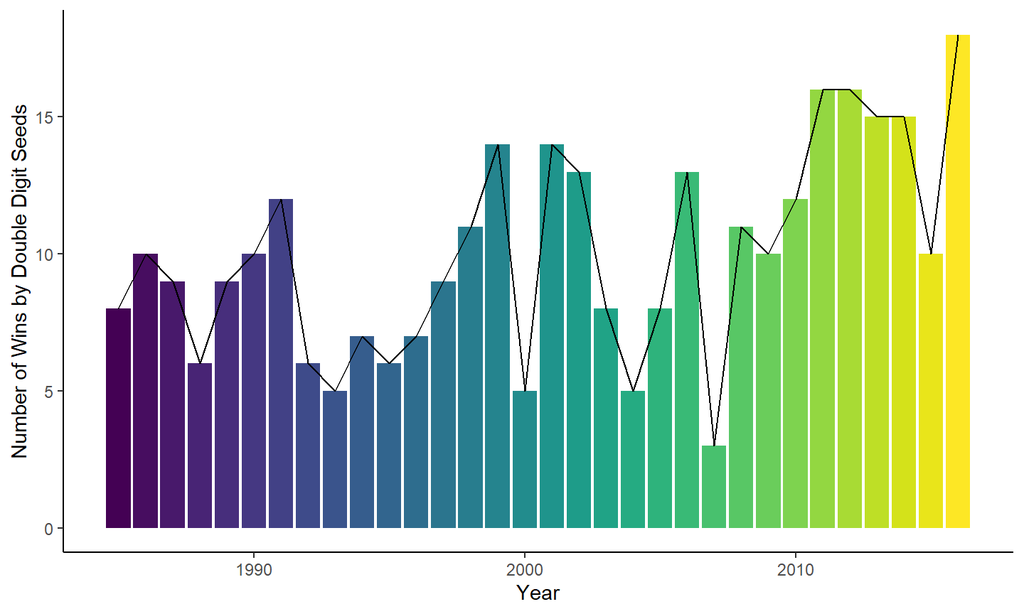

# Analysis

This bar graph displays the total number of games won by teams seeded between 10-16 (double digit seeds) in each March Madness tournament from 1985-2016. This graph is seeking to analyze if lower seeded teams have experienced more success in March Madness over time, which can be a good indicator that the playing field is leveling and becoming more competitive.

The main takeaway from this graph is that lower seeded teams have won more games in the latter part of the games in our dataset than they did in the former. From 1985-1990, double digit seeded teams won noticeably less games than they did from 2010-2016. This suggests that the gap between higher seeded teams and lower seeded teams has narrowed considerably over time, and that double digit seeds’ chance of winning games has increased over time. Therefore, this leads me to conclude that March Madness HAS become more competitive over time, as double digit seeds are winning more games over time, which is a prime indicator that the gap between single digit seeds and double digit seeds has narrowed over time and the tournament is becoming more competitive.

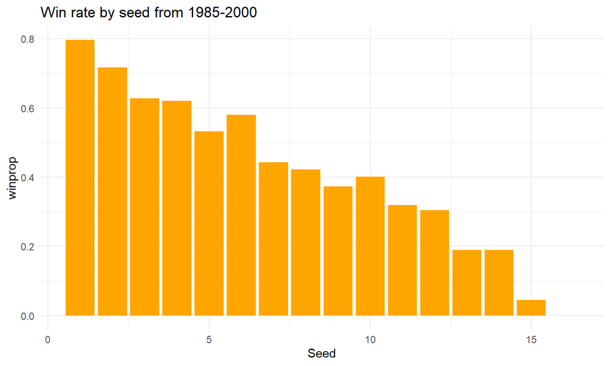

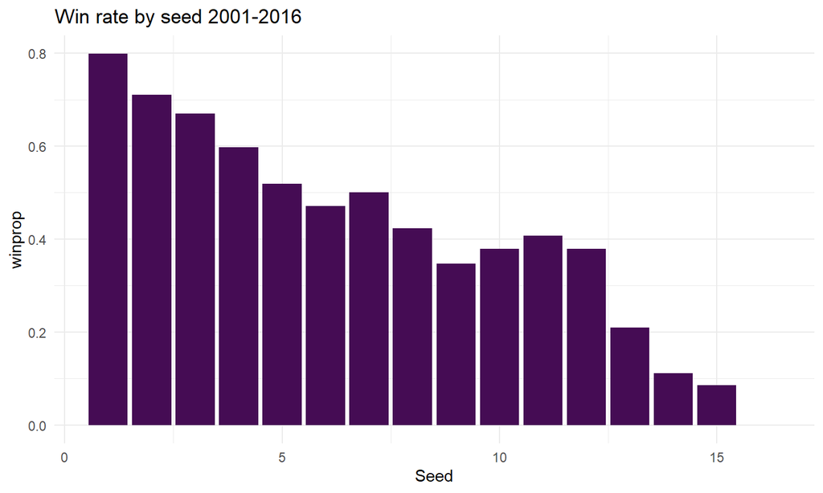

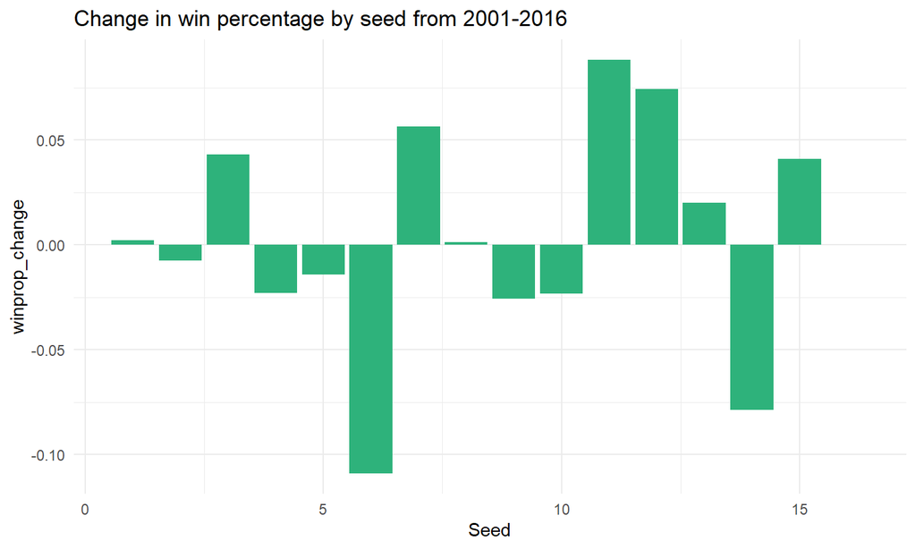

```r
MarchMadness %>% with(lm(ScoreDifferential ~ Year))
```

```
##
## Call:
## lm(formula = ScoreDifferential ~ Year)
##
## Coefficients:
## (Intercept)         Year
##     -1.9180       0.0068
```

## Analysis

Constructing a linear regression model with score differential as the outcome variable and year as the predictor variable reveals that score differential increases by .0068 points per year. While this number is quite small, it still suggests that March Madness games are not becoming more competitive over time, but are actually becoming less competitive as the score margin of games increases.